# Microsensing

2024-04-11

```r
library(readr)
library(dplyr)
```

```r
library(ggplot2)
library(gridExtra)
```

## First Dataset, 4/10/24

Analyze dataset from 4/10/24, for the gels made on 4/8/24. There is an n = 3 for each thickness, with 3 gels of 200 um thickness (“thin”) and 3 gels of 1000 um thickness (“thick”). Three profiles were taken per gel, at a light intensity of PAR” 90 umol/m^2/s and a flow rate of 0.5 cm/s. Three additional profiles were taken per gel in the dark after 20 minutes of dark adaptation. The profiles were taken in the middle of the hydrogel, in the same position for all 6 profiles per gel.

### Plotting profiles

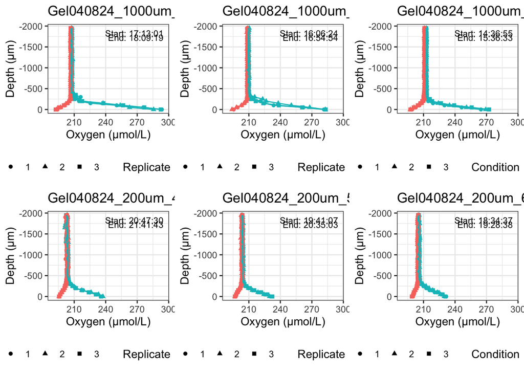

```r
files <- list.files(path = "./Polymerized040824_Measured041024", pattern = "\\.csv$", full.names = TRUE)

plot_list <- list()

for (file in files) {
  file_name <- tools::file_path_sans_ext(basename(file))

  file_data <- read_csv(paste(file),show_col_types = FALSE) %>%
    mutate(Replicate = as.factor(Replicate)) %>%
    rename("Oxygen (µmol/L)" = `A FireSting Ch1 (µmol/L)`)

  plot <- ggplot(data = file_data, aes(y = `Oxygen (µmol/L)`, x = `Depth (µm)`,
                                       color = `Condition`, shape = `Replicate`)) +
      geom_point() + geom_line() +
      coord_flip() + scale_x_reverse() + ylim(190, 295) +
      theme_bw() + ggtitle(file_name) +
      annotate("text", x = -1900, y = 295, label = paste("Start:", file_data$Time[1]), vjust = 1, hjust = 1, size = 3) +
      annotate("text", x = -1800, y = 295, label = paste("End:", file_data$Time[nrow(file_data)]), vjust = 1, hjust = 1, size = 3) +
    theme(legend.position = "bottom")

  #print(plot)

  plot_list[[file_name]] <- plot
}
arranged_plots <- arrangeGrob(grobs = plot_list, ncol = 3)

gridExtra::grid.arrange(arranged_plots)
```

```r
ggsave("Polymerized040824_Measured041024_plots.pdf", arranged_plots, width = 16, height = 9, units = "in", device = "pdf")
```

### Notes about calculating flux

Wangpraseurt et al 2022: For each profile, the diffusive O2 flux was calculated using Fick’s first law of diffusion as described previously[31] (using a diffusion coefficient of DO2 = 2.2417 × 10−5). The effective DBL thickness δe as the intersection between the extrapolation of the linear part of the O2 slope within the boundary layer that intercepts with the O2 concentration of the bulk medium was calculated.[75]

75 - B. B. Jørgensen, N. P. Revsbech, Limnol. Oceanogr.1985, 30, 111.

31 - D. Wangpraseurt, S. You, F. Azam, G. Jacucci, O. Gaidarenko, M. Hildebrand, M. Kühl, A. G. Smith, M. P. Davey, A. Smith, D. D. Deheyn, S. Chen, S. Vignolini, Nat. Commun. 2020, 11, 1748.

“The diffusive O2 ﬂux was calculated via Fick’s ﬁrst law of diffusion for a water temperature = 25 °C and salinity = 30 using a molecular diffusion coefﬁcient for O2 = 2.255 × 10−5 cm2 s−1(2). Gross photosynthesis was estimated via the light-dark shift method36. A ﬂow chamber set-up provided slow laminar ﬂow (ﬂow rate = 0.5 cm s−1) and a ﬁber-optic halogen lamp (Schott KL2500, Schott, Germany) provided white light at deﬁned levels of incident irradiance (400–700 nm) (0, 110, 220, and 1200 µmol photons m−2 s−1)2. Photosynthesis-irradiance curves were ﬁtted to an exponential function37.”

### Attempt to calculate flux

For the thick ones I am calculating the layer as at -250

```r
# Get list of files for 1000um gels in the directory
files <- list.files(path = "./Polymerized040824_Measured041024", pattern = "^Gel040824_1000um_\\d\\.csv$")

# Create an empty dataframe to store results

results_df_1000um <- data.frame(
  File = character(),
  Scaffold_Thickness = character(),
  Replicate = character(),
  Flux = numeric(),
  END_DBL = numeric(),
  Oxygen_Surface = numeric(),
  Oxygen_End_DBL = numeric()
)

# Loop over each file
for (file in files) {
  # Read the file
  data <- read_csv(paste0("./Polymerized040824_Measured041024/",file), show_col_types = FALSE) %>%
    mutate(Replicate = as.factor(Replicate)) %>%
    rename("Oxygen (µmol/L)" = `A FireSting Ch1 (µmol/L)`)

  # Loop over each replicate
  for (replicate in unique(data$Replicate)) {
    # Filter data for the current replicate and condition
    oxygen_concentration <- data %>%
      filter(Replicate == replicate & Condition == "Light", `Depth (µm)` > -300) %>%
      pull(`Oxygen (µmol/L)`)
    depth <- data %>%
      filter(Replicate == replicate & Condition == "Light", `Depth (µm)` > -300) %>%
      pull(`Depth (µm)`)

    # Fit a linear regression model to estimate the slope within the diffusive boundary layer
    boundary_layer_lm <- lm(oxygen_concentration ~ depth)
    slope <- coef(boundary_layer_lm)[[2]]

    # Calculate flux using Fick’s first law of diffusion
    DO2 <- 2.2417e-5  # Diffusion coefficient of oxygen
    flux <- -DO2 * slope

    # Add the result to the dataframe
    results_df_1000um <- rbind(
      results_df_1000um,
      data.frame(
        File = file,
        Scaffold_Thickness = "1000 um",
        Replicate = replicate,
        Flux = flux,
        END_DBL = min(depth),
        Oxygen_Surface = max(oxygen_concentration),
        Oxygen_End_DBL = min(oxygen_concentration)
      )
    )
  }
}
results_df_1000um
```

```
##                     File Scaffold_Thickness Replicate          Flux END_DBL
## 1 Gel040824_1000um_4.csv            1000 um         1 -7.701213e-06    -250
## 2 Gel040824_1000um_4.csv            1000 um         2 -6.662409e-06    -250
## 3 Gel040824_1000um_4.csv            1000 um         3 -7.801359e-06    -250
## 4 Gel040824_1000um_5.csv            1000 um         1 -5.981432e-06    -250
## 5 Gel040824_1000um_5.csv            1000 um         2 -5.574327e-06    -250
## 6 Gel040824_1000um_5.csv            1000 um         3 -6.463321e-06    -250
## 7 Gel040824_1000um_6.csv            1000 um         1 -4.645738e-06    -250
## 8 Gel040824_1000um_6.csv            1000 um         2 -5.009059e-06    -250
## 9 Gel040824_1000um_6.csv            1000 um         3 -5.224788e-06    -250
##   Oxygen_Surface Oxygen_End_DBL
## 1        293.493        214.610
## 2        285.615        212.969
## 3        292.447        209.878
## 4        281.456        214.343
## 5        282.833        223.194
## 6        283.175        211.752
## 7        264.643        213.406
## 8        269.245        213.521
## 9        272.468        215.985
```

For the thinner ones, I am calculating with the boundary later at -400

```r
# Get list of files for 200um gels in the directory
files <- list.files(path = "./Polymerized040824_Measured041024", pattern = "^Gel040824_200um_\\d\\.csv$")

# Create an empty dataframe to store results

results_df_200um <- data.frame(
  File = character(),
  Scaffold_Thickness = character(),
  Replicate = character(),
  Flux = numeric(),
  END_DBL = numeric(),
  Oxygen_Surface = numeric(),
  Oxygen_End_DBL = numeric()
)

# Loop over each file
for (file in files) {
  # Read the file
  data <- read_csv(paste0("./Polymerized040824_Measured041024/",file), show_col_types = FALSE) %>%
    mutate(Replicate = as.factor(Replicate)) %>%
    rename("Oxygen (µmol/L)" = `A FireSting Ch1 (µmol/L)`)

  # Loop over each replicate
  for (replicate in unique(data$Replicate)) {
    # Filter data for the current replicate and condition
    oxygen_concentration <- data %>%
      filter(Replicate == replicate & Condition == "Light", `Depth (µm)` > -450) %>%
      pull(`Oxygen (µmol/L)`)
    depth <- data %>%
      filter(Replicate == replicate & Condition == "Light", `Depth (µm)` > -450) %>%
      pull(`Depth (µm)`)

    # Fit a linear regression model to estimate the slope within the diffusive boundary layer
    boundary_layer_lm <- lm(oxygen_concentration ~ depth)
    slope <- coef(boundary_layer_lm)[[2]]

    # Calculate flux using Fick’s first law of diffusion
    DO2 <- 2.2417e-5  # Diffusion coefficient of oxygen
    flux <- -DO2 * slope

    # Add the result to the dataframe
    results_df_200um <- rbind(
      results_df_200um,
      data.frame(
        File = file,
        Scaffold_Thickness = "200 um",
        Replicate = replicate,
        Flux = flux,
        END_DBL = min(depth),
        Oxygen_Surface = max(oxygen_concentration),
        Oxygen_End_DBL = min(oxygen_concentration)
      )
    )
  }
}
results_df_200um
```

```
##                    File Scaffold_Thickness Replicate          Flux END_DBL
## 1 Gel040824_200um_4.csv             200 um         1 -1.848513e-06    -400
## 2 Gel040824_200um_4.csv             200 um         2 -1.999933e-06    -400
## 3 Gel040824_200um_4.csv             200 um         3 -1.833038e-06    -400
## 4 Gel040824_200um_5.csv             200 um         1 -1.499294e-06    -400
## 5 Gel040824_200um_5.csv             200 um         2 -1.423450e-06    -400
## 6 Gel040824_200um_5.csv             200 um         3 -1.639520e-06    -400
## 7 Gel040824_200um_6.csv             200 um         1 -1.447600e-06    -400
## 8 Gel040824_200um_6.csv             200 um         2 -1.388449e-06    -400
## 9 Gel040824_200um_6.csv             200 um         3 -1.516301e-06    -400
##   Oxygen_Surface Oxygen_End_DBL
## 1        235.138        204.172
## 2        237.367        204.110
## 3        235.725        204.696
## 4        230.437        204.200
## 5        229.684        204.580
## 6        232.367        204.267
## 7        231.559        206.548
## 8        229.721        205.829
## 9        230.814        206.309
```

### Plotting

```r
Full_results <- rbind(results_df_1000um, results_df_200um)

Full_results
```

```
##                      File Scaffold_Thickness Replicate          Flux END_DBL
## 1  Gel040824_1000um_4.csv            1000 um         1 -7.701213e-06    -250
## 2  Gel040824_1000um_4.csv            1000 um         2 -6.662409e-06    -250
## 3  Gel040824_1000um_4.csv            1000 um         3 -7.801359e-06    -250
## 4  Gel040824_1000um_5.csv            1000 um         1 -5.981432e-06    -250
## 5  Gel040824_1000um_5.csv            1000 um         2 -5.574327e-06    -250
## 6  Gel040824_1000um_5.csv            1000 um         3 -6.463321e-06    -250
## 7  Gel040824_1000um_6.csv            1000 um         1 -4.645738e-06    -250
## 8  Gel040824_1000um_6.csv            1000 um         2 -5.009059e-06    -250
## 9  Gel040824_1000um_6.csv            1000 um         3 -5.224788e-06    -250
## 10  Gel040824_200um_4.csv             200 um         1 -1.848513e-06    -400
## 11  Gel040824_200um_4.csv             200 um         2 -1.999933e-06    -400
## 12  Gel040824_200um_4.csv             200 um         3 -1.833038e-06    -400
## 13  Gel040824_200um_5.csv             200 um         1 -1.499294e-06    -400
## 14  Gel040824_200um_5.csv             200 um         2 -1.423450e-06    -400
```

[output cut: 23 more lines]

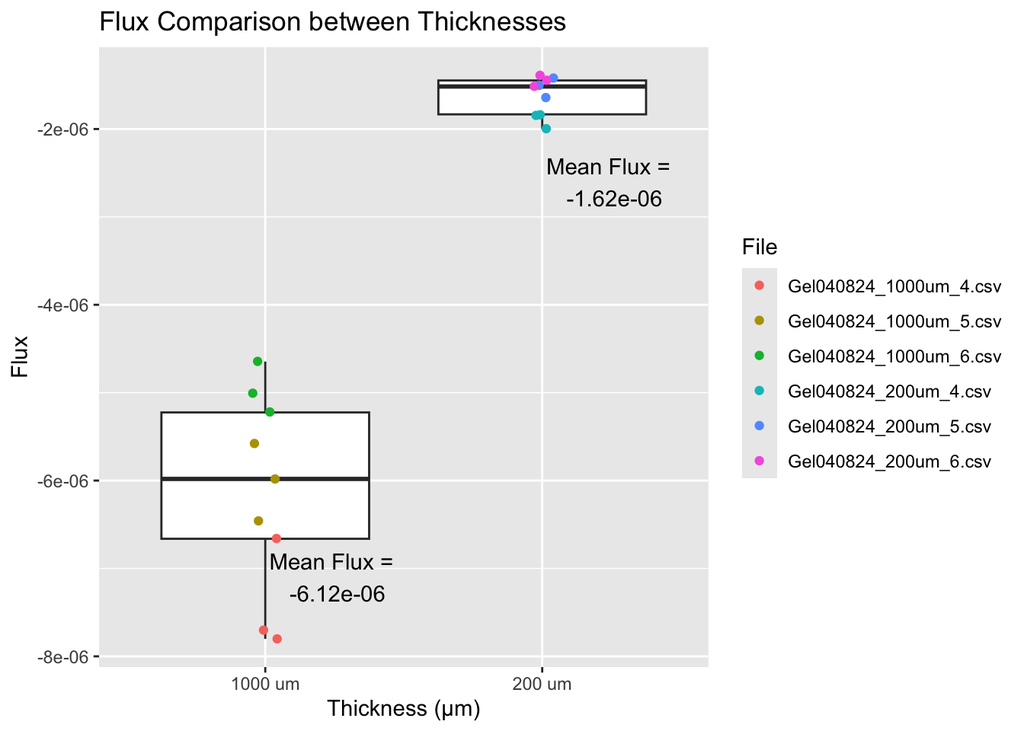

```r
mean_flux <- Full_results %>%
  group_by(Scaffold_Thickness) %>%
  summarize(mean_flux = mean(Flux))

# Plotting the flux values for each thickness
ggplot(Full_results, aes(x = Scaffold_Thickness, y = Flux)) +
  geom_boxplot() + geom_point(aes(color = File), position = position_jitter(width = 0.05)) +
  geom_text(data = mean_flux, aes(label = paste("Mean Flux = \n", sprintf("%.2e", mean_flux)), y = mean_flux-.0000012), vjust = 0.1, position = position_nudge(x = 0.25)) +
  labs(x = "Thickness (µm)", y = "Flux") +
  ggtitle("Flux Comparison between Thicknesses")
```

```r
# Running ANOVA
anova_result <- aov(Flux ~ Scaffold_Thickness, data = Full_results)
summary(anova_result)
```

```
##                    Df    Sum Sq   Mean Sq F value   Pr(>F)
## Scaffold_Thickness  1 9.098e-11 9.098e-11   136.6 3.01e-09 ***
## Residuals          16 1.065e-11 6.700e-13
## ---
## Signif. codes:  0 '***' 0.001 '**' 0.01 '*' 0.05 '.' 0.1 ' ' 1
```

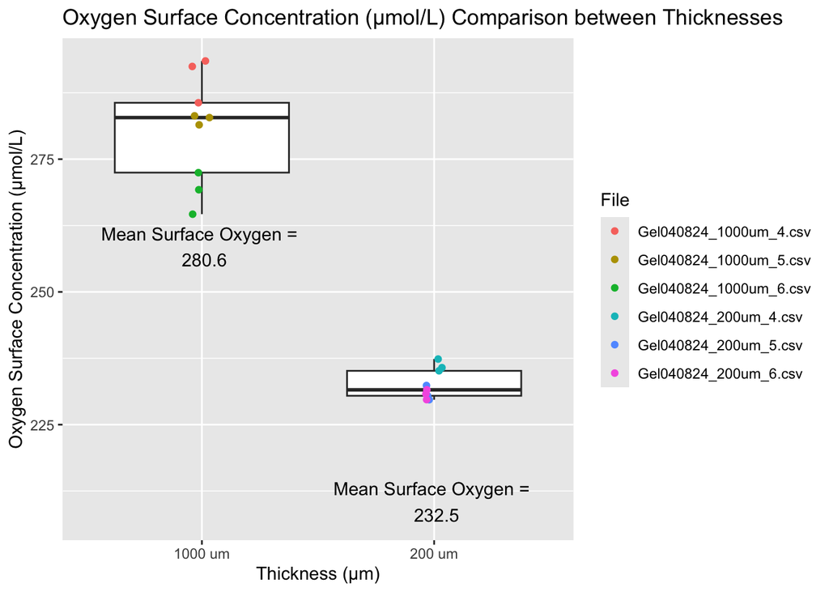

```r
# What about for oxygen surface concentration?

mean_Oxygen_Surface <- Full_results %>%
  group_by(Scaffold_Thickness) %>%
  summarize(mean_Oxygen_Surface = mean(Oxygen_Surface))

# Plotting the surface O2 values for each thickness
ggplot(Full_results, aes(x = Scaffold_Thickness, y = Oxygen_Surface)) +
  geom_boxplot() + geom_point(aes(color = File), position = position_jitter(width = 0.05)) +
  geom_text(data = mean_Oxygen_Surface, aes(label = paste("Mean Surface Oxygen = \n", round(mean_Oxygen_Surface, 1)), y = mean_Oxygen_Surface-25), vjust = 0.1, position = position_nudge(x = 0.0)) +
  labs(x = "Thickness (µm)", y = "Oxygen Surface Concentration (µmol/L)") +
  ggtitle("Oxygen Surface Concentration (µmol/L) Comparison between Thicknesses")
```

```r
# Running ANOVA
anova_result <- aov(Oxygen_Surface ~ Scaffold_Thickness, data = Full_results)
summary(anova_result)
```

```
##                    Df Sum Sq Mean Sq F value   Pr(>F)
## Scaffold_Thickness  1  10395   10395   193.7 2.33e-10 ***
## Residuals          16    858      54
## ---
## Signif. codes:  0 '***' 0.001 '**' 0.01 '*' 0.05 '.' 0.1 ' ' 1
```

### Using segmented linear regression, segmented R package

```r
library(segmented)
results_df_1000um_segmented <- data.frame(
  File = character(),
  Scaffold_Thickness = character(),
  Replicate = character(),
  slope = numeric(),
  Flux = numeric(),
  Breakpoint = numeric(),
  Oxygen_Surface = numeric(),
  Oxygen_breakpoint = numeric(),
  stringsAsFactors = FALSE
)

# Function to perform segmented regression and extract slope after breakpoint
perform_segmented_regression <- function(oxygen_concentration, depth) {
  # Fit segmented regression model
  fit <- segmented(lm(oxygen_concentration ~ depth), seg.Z = ~depth, psi = -250)

  # Extract the breakpoint(s)
  breakpoint <- fit$psi[, 2]

  # Find the index of the datapoint nearest to the breakpoint
  breakpoint_index <- which.min(abs(depth - breakpoint))

  # Extract the oxygen concentration at the breakpoint
  Oxygen_breakpoint <- oxygen_concentration[breakpoint_index]

  # Extract the oxygen concentration at depth = 0
  Oxygen_Surface <- oxygen_concentration[which(depth == 0)]

  # Extract the slope after the breakpoint for each segment
  lm_fit <- lm(oxygen_concentration ~ depth,
                 data = data.frame(depth = depth[breakpoint_index:length(depth)],
                                   oxygen_concentration = oxygen_concentration[breakpoint_index:length(oxygen_concentration)]))
  slope <- coef(lm_fit)["depth"]

  return(list(
    slope = slope,
    breakpoint = breakpoint,
    Oxygen_breakpoint = Oxygen_breakpoint,
    Oxygen_Surface = Oxygen_Surface
  ))
}

# Get list of CSV file names with "1000" in the title
file_list <- list.files(path = "./Polymerized040824_Measured041024", pattern = "1000.*\\.csv$", full.names = TRUE)

# Loop over files
for (file_path in file_list) {
  # Read data from file
  data <- read_csv(file_path, show_col_types = FALSE) %>%
    mutate(Replicate = as.factor(Replicate)) %>%
    rename("Oxygen (µmol/L)" = `A FireSting Ch1 (µmol/L)`) %>%
    arrange(`Depth (µm)`)

  # Loop over replicates
  for (replicate_id in unique(data$Replicate)) {
    # Subset data for the current replicate
    replicate_data <- data %>%
      filter(Replicate == replicate_id & Condition == "Light")

    # Extract oxygen concentration and depth
    oxygen_concentration <- replicate_data %>% pull(`Oxygen (µmol/L)`)
    depth <- replicate_data %>% pull(`Depth (µm)`)

    # Perform segmented regression
    regression_results <- perform_segmented_regression(oxygen_concentration, depth)

    # Calculate flux using Fick’s first law of diffusion
    DO2 <- 2.2417e-5  # Diffusion coefficient of oxygen
    flux <- -DO2 * regression_results$slope

    # Store results in dataframe
    results_df_1000um_segmented <- bind_rows(results_df_1000um_segmented, data.frame(
      File = basename(file_path),
      Scaffold_Thickness = "1000 um",
      Replicate = replicate_id,
      slope = regression_results$slope,
      Flux = flux,
      Breakpoint = regression_results$breakpoint,
      Oxygen_Surface = regression_results$Oxygen_Surface,
      Oxygen_breakpoint = regression_results$Oxygen_breakpoint,
      stringsAsFactors = FALSE
    ))
  }
}
# Print the results dataframe
print(results_df_1000um_segmented)
```

```
##                             File Scaffold_Thickness Replicate     slope
## depth...1 Gel040824_1000um_4.csv            1000 um         1 0.4163000
## depth...2 Gel040824_1000um_4.csv            1000 um         2 0.2972034
## depth...3 Gel040824_1000um_4.csv            1000 um         3 0.3480109
## depth...4 Gel040824_1000um_5.csv            1000 um         1 0.3158300
## depth...5 Gel040824_1000um_5.csv            1000 um         2 0.2252707
## depth...6 Gel040824_1000um_5.csv            1000 um         3 0.3405020
## depth...7 Gel040824_1000um_6.csv            1000 um         1 0.3064920
## depth...8 Gel040824_1000um_6.csv            1000 um         2 0.2625240
## depth...9 Gel040824_1000um_6.csv            1000 um         3 0.2755740
##                    Flux Breakpoint Oxygen_Surface Oxygen_breakpoint
## depth...1 -9.332197e-06  -186.4981        293.493           214.610
## depth...2 -6.662409e-06  -228.7611        285.615           212.969
## depth...3 -7.801359e-06  -226.2641        292.447           209.878
## depth...4 -7.079961e-06  -207.0086        281.456           221.030
## depth...5 -5.049894e-06  -276.5534        282.833           215.546
## depth...6 -7.633033e-06  -176.8002        283.175           216.541
## depth...7 -6.870631e-06  -162.7789        264.643           219.004
## depth...8 -5.885001e-06  -178.6104        269.245           217.059
## depth...9 -6.177542e-06  -207.1288        272.468           218.221
```

```r
print(results_df_1000um)
```

```
##                     File Scaffold_Thickness Replicate          Flux END_DBL
## 1 Gel040824_1000um_4.csv            1000 um         1 -7.701213e-06    -250
## 2 Gel040824_1000um_4.csv            1000 um         2 -6.662409e-06    -250
## 3 Gel040824_1000um_4.csv            1000 um         3 -7.801359e-06    -250
## 4 Gel040824_1000um_5.csv            1000 um         1 -5.981432e-06    -250
## 5 Gel040824_1000um_5.csv            1000 um         2 -5.574327e-06    -250
## 6 Gel040824_1000um_5.csv            1000 um         3 -6.463321e-06    -250
## 7 Gel040824_1000um_6.csv            1000 um         1 -4.645738e-06    -250
## 8 Gel040824_1000um_6.csv            1000 um         2 -5.009059e-06    -250
## 9 Gel040824_1000um_6.csv            1000 um         3 -5.224788e-06    -250
##   Oxygen_Surface Oxygen_End_DBL
## 1        293.493        214.610
## 2        285.615        212.969
## 3        292.447        209.878
## 4        281.456        214.343
## 5        282.833        223.194
## 6        283.175        211.752
## 7        264.643        213.406
## 8        269.245        213.521
## 9        272.468        215.985
```

```r
results_df_200um_segmented <- data.frame(
  File = character(),
  Scaffold_Thickness = character(),
  Replicate = character(),
  slope = numeric(),
  Flux = numeric(),
  Breakpoint = numeric(),
  Oxygen_Surface = numeric(),
  Oxygen_breakpoint = numeric(),
  stringsAsFactors = FALSE
)

# Function to perform segmented regression and extract slope after breakpoint
perform_segmented_regression <- function(oxygen_concentration, depth) {
  # Fit segmented regression model
  fit <- segmented(lm(oxygen_concentration ~ depth), seg.Z = ~depth, psi = -400)

  # Extract the breakpoint(s)
  breakpoint <- fit$psi[, 2]

  # Find the index of the datapoint nearest to the breakpoint
  breakpoint_index <- which.min(abs(depth - breakpoint))

  # Extract the oxygen concentration at the breakpoint
  Oxygen_breakpoint <- oxygen_concentration[breakpoint_index]

  # Extract the oxygen concentration at depth = 0
  Oxygen_Surface <- oxygen_concentration[which(depth == 0)]

  # Extract the slope after the breakpoint for each segment
  lm_fit <- lm(oxygen_concentration ~ depth,
                 data = data.frame(depth = depth[breakpoint_index:length(depth)],
                                   oxygen_concentration = oxygen_concentration[breakpoint_index:length(oxygen_concentration)]))
  slope <- coef(lm_fit)["depth"]

  return(list(
    slope = slope,
    breakpoint = breakpoint,
    Oxygen_breakpoint = Oxygen_breakpoint,
    Oxygen_Surface = Oxygen_Surface
  ))
}

# Get list of CSV file names with "200" in the title
file_list <- list.files(path = "./Polymerized040824_Measured041024", pattern = "200.*\\.csv$", full.names = TRUE)

# Loop over files
for (file_path in file_list) {
  # Read data from file
  data <- read_csv(file_path, show_col_types = FALSE) %>%
    mutate(Replicate = as.factor(Replicate)) %>%
    rename("Oxygen (µmol/L)" = `A FireSting Ch1 (µmol/L)`) %>%
    arrange(`Depth (µm)`)

  # Loop over replicates
  for (replicate_id in unique(data$Replicate)) {
    # Subset data for the current replicate
    replicate_data <- data %>%
      filter(Replicate == replicate_id & Condition == "Light")

    # Extract oxygen concentration and depth
    oxygen_concentration <- replicate_data %>% pull(`Oxygen (µmol/L)`)
    depth <- replicate_data %>% pull(`Depth (µm)`)

    # Perform segmented regression
    regression_results <- perform_segmented_regression(oxygen_concentration, depth)

    # Calculate flux using Fick’s first law of diffusion
    DO2 <- 2.2417e-5  # Diffusion coefficient of oxygen
    flux <- -DO2 * regression_results$slope

    # Store results in dataframe
    results_df_200um_segmented <- bind_rows(results_df_200um_segmented, data.frame(
      File = basename(file_path),
      Scaffold_Thickness = "200 um",
      Replicate = replicate_id,
      slope = regression_results$slope,
      Flux = flux,
      Breakpoint = regression_results$breakpoint,
      Oxygen_Surface = regression_results$Oxygen_Surface,
      Oxygen_breakpoint = regression_results$Oxygen_breakpoint,
      stringsAsFactors = FALSE
    ))
  }
}
# Print the results dataframe
print(results_df_200um_segmented)
```

```
##                            File Scaffold_Thickness Replicate      slope
## depth...1 Gel040824_200um_4.csv             200 um         1 0.10182714
## depth...2 Gel040824_200um_4.csv             200 um         2 0.12417314
## depth...3 Gel040824_200um_4.csv             200 um         3 0.11439429
## depth...4 Gel040824_200um_5.csv             200 um         1 0.09876400
## depth...5 Gel040824_200um_5.csv             200 um         2 0.09298171
## depth...6 Gel040824_200um_5.csv             200 um         3 0.10329143
## depth...7 Gel040824_200um_6.csv             200 um         1 0.09034171
## depth...8 Gel040824_200um_6.csv             200 um         2 0.06573738
## depth...9 Gel040824_200um_6.csv             200 um         3 0.08116286
##                    Flux Breakpoint Oxygen_Surface Oxygen_breakpoint
## depth...1 -2.282659e-06  -278.3708        235.138           206.914
## depth...2 -2.783589e-06  -269.4554        237.367           208.720
## depth...3 -2.564377e-06  -269.4545        235.725           208.342
## depth...4 -2.213993e-06  -236.2531        230.437           206.340
## depth...5 -2.084371e-06  -237.5620        229.684           207.066
## depth...6 -2.315484e-06  -266.7288        232.367           207.491
## depth...7 -2.025190e-06  -274.4906        231.559           209.808
## depth...8 -1.473635e-06  -340.0699        229.721           207.371
## depth...9 -1.819428e-06  -310.8676        230.814           207.816
```

```r
print(results_df_200um)
```

```
##                    File Scaffold_Thickness Replicate          Flux END_DBL
## 1 Gel040824_200um_4.csv             200 um         1 -1.848513e-06    -400
## 2 Gel040824_200um_4.csv             200 um         2 -1.999933e-06    -400
## 3 Gel040824_200um_4.csv             200 um         3 -1.833038e-06    -400
## 4 Gel040824_200um_5.csv             200 um         1 -1.499294e-06    -400
## 5 Gel040824_200um_5.csv             200 um         2 -1.423450e-06    -400
## 6 Gel040824_200um_5.csv             200 um         3 -1.639520e-06    -400
## 7 Gel040824_200um_6.csv             200 um         1 -1.447600e-06    -400
## 8 Gel040824_200um_6.csv             200 um         2 -1.388449e-06    -400
## 9 Gel040824_200um_6.csv             200 um         3 -1.516301e-06    -400
##   Oxygen_Surface Oxygen_End_DBL
## 1        235.138        204.172
## 2        237.367        204.110
## 3        235.725        204.696
## 4        230.437        204.200
## 5        229.684        204.580
## 6        232.367        204.267
## 7        231.559        206.548
## 8        229.721        205.829
## 9        230.814        206.309
```

```r
Full_results_segmented <- rbind(results_df_1000um_segmented, results_df_200um_segmented)

Full_results_segmented
```

```
##                              File Scaffold_Thickness Replicate      slope
## depth...1  Gel040824_1000um_4.csv            1000 um         1 0.41630000
## depth...2  Gel040824_1000um_4.csv            1000 um         2 0.29720343
## depth...3  Gel040824_1000um_4.csv            1000 um         3 0.34801086
## depth...4  Gel040824_1000um_5.csv            1000 um         1 0.31583000
## depth...5  Gel040824_1000um_5.csv            1000 um         2 0.22527071
## depth...6  Gel040824_1000um_5.csv            1000 um         3 0.34050200
## depth...7  Gel040824_1000um_6.csv            1000 um         1 0.30649200
## depth...8  Gel040824_1000um_6.csv            1000 um         2 0.26252400
## depth...9  Gel040824_1000um_6.csv            1000 um         3 0.27557400
## depth...11  Gel040824_200um_4.csv             200 um         1 0.10182714
## depth...21  Gel040824_200um_4.csv             200 um         2 0.12417314
## depth...31  Gel040824_200um_4.csv             200 um         3 0.11439429
## depth...41  Gel040824_200um_5.csv             200 um         1 0.09876400
## depth...51  Gel040824_200um_5.csv             200 um         2 0.09298171
## depth...61  Gel040824_200um_5.csv             200 um         3 0.10329143
## depth...71  Gel040824_200um_6.csv             200 um         1 0.09034171
## depth...81  Gel040824_200um_6.csv             200 um         2 0.06573738
## depth...91  Gel040824_200um_6.csv             200 um         3 0.08116286
##                     Flux Breakpoint Oxygen_Surface Oxygen_breakpoint
## depth...1  -9.332197e-06  -186.4981        293.493           214.610
## depth...2  -6.662409e-06  -228.7611        285.615           212.969
## depth...3  -7.801359e-06  -226.2641        292.447           209.878
## depth...4  -7.079961e-06  -207.0086        281.456           221.030
## depth...5  -5.049894e-06  -276.5534        282.833           215.546
## depth...6  -7.633033e-06  -176.8002        283.175           216.541
## depth...7  -6.870631e-06  -162.7789        264.643           219.004
## depth...8  -5.885001e-06  -178.6104        269.245           217.059
## depth...9  -6.177542e-06  -207.1288        272.468           218.221
## depth...11 -2.282659e-06  -278.3708        235.138           206.914
## depth...21 -2.783589e-06  -269.4554        237.367           208.720
## depth...31 -2.564377e-06  -269.4545        235.725           208.342
## depth...41 -2.213993e-06  -236.2531        230.437           206.340
## depth...51 -2.084371e-06  -237.5620        229.684           207.066
## depth...61 -2.315484e-06  -266.7288        232.367           207.491
## depth...71 -2.025190e-06  -274.4906        231.559           209.808
## depth...81 -1.473635e-06  -340.0699        229.721           207.371
## depth...91 -1.819428e-06  -310.8676        230.814           207.816
```

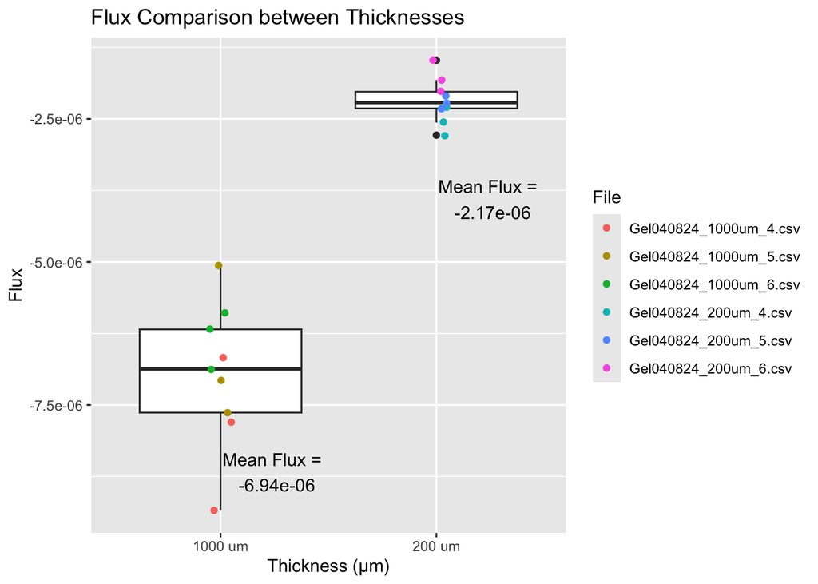

```r
mean_flux <- Full_results_segmented %>%
  group_by(Scaffold_Thickness) %>%
  summarize(mean_flux = mean(Flux))

# Plotting the flux values for each thickness
ggplot(Full_results_segmented, aes(x = Scaffold_Thickness, y = Flux)) +
  geom_boxplot() + geom_point(aes(color = File), position = position_jitter(width = 0.05)) +
  geom_text(data = mean_flux, aes(label = paste("Mean Flux = \n", sprintf("%.2e", mean_flux)), y = mean_flux-.000002), vjust = 0.1, position = position_nudge(x = 0.25)) +
  labs(x = "Thickness (µm)", y = "Flux") +
  ggtitle("Flux Comparison between Thicknesses")
```

```r
# Running ANOVA
anova_result <- aov(Flux ~ Scaffold_Thickness, data = Full_results_segmented)
summary(anova_result)
```

```
##                    Df    Sum Sq   Mean Sq F value  Pr(>F)
## Scaffold_Thickness  1 1.024e-10 1.024e-10   121.2 7.1e-09 ***
## Residuals          16 1.352e-11 8.400e-13
## ---
## Signif. codes:  0 '***' 0.001 '**' 0.01 '*' 0.05 '.' 0.1 ' ' 1
```

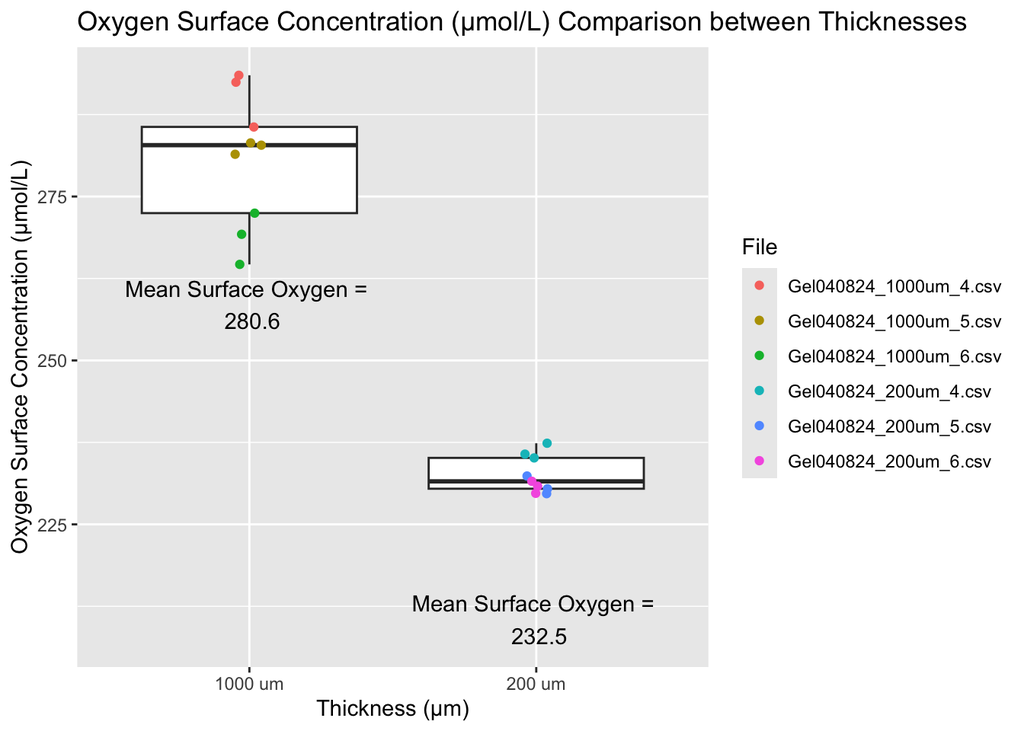

```r
# What about for oxygen surface concentration?

mean_Oxygen_Surface <- Full_results_segmented %>%
  group_by(Scaffold_Thickness) %>%
  summarize(mean_Oxygen_Surface = mean(Oxygen_Surface))

# Plotting the surface O2 values for each thickness
ggplot(Full_results_segmented, aes(x = Scaffold_Thickness, y = Oxygen_Surface)) +
  geom_boxplot() + geom_point(aes(color = File), position = position_jitter(width = 0.05)) +
  geom_text(data = mean_Oxygen_Surface, aes(label = paste("Mean Surface Oxygen = \n", round(mean_Oxygen_Surface, 1)), y = mean_Oxygen_Surface-25), vjust = 0.1, position = position_nudge(x = 0.0)) +
  labs(x = "Thickness (µm)", y = "Oxygen Surface Concentration (µmol/L)") +
  ggtitle("Oxygen Surface Concentration (µmol/L) Comparison between Thicknesses")
```

```r
# Running ANOVA
anova_result <- aov(Oxygen_Surface ~ Scaffold_Thickness, data = Full_results_segmented)
summary(anova_result)
```

```
##                    Df Sum Sq Mean Sq F value   Pr(>F)
## Scaffold_Thickness  1  10395   10395   193.7 2.33e-10 ***
## Residuals          16    858      54
## ---
## Signif. codes:  0 '***' 0.001 '**' 0.01 '*' 0.05 '.' 0.1 ' ' 1
```

### Plotting profiles with DBL

```r
files <- list.files(path = "./Polymerized040824_Measured041024", pattern = "\\.csv$", full.names = TRUE)

plot_list <- list()

for (file in files) {
  file_name <- tools::file_path_sans_ext(basename(file))

  file_data <- read_csv(paste(file),show_col_types = FALSE) %>%
    mutate(Replicate = as.factor(Replicate)) %>%
    rename("Oxygen (µmol/L)" = `A FireSting Ch1 (µmol/L)`)

  # Extract the DBL depth for the current file
  dbl_depth <- Full_results_segmented$Breakpoint[gsub("\\.csv$", "", Full_results_segmented$File) == file_name]

  plot <- ggplot(data = file_data, aes(y = `Oxygen (µmol/L)`, x = `Depth (µm)`,
                                       color = `Condition`, shape = `Replicate`)) +
      geom_point() + geom_line() +
      coord_flip() + scale_x_reverse() + ylim(190, 295) + xlim(0, -750) +
      theme_bw() + ggtitle(file_name) +
      annotate("text", x = -650, y = 295, label = paste("Start:", file_data$Time[1]), vjust = 1, hjust = 1, size = 3) +
      annotate("text", x = -550, y = 295, label = paste("End:", file_data$Time[nrow(file_data)]), vjust = 1, hjust = 1, size = 3) +
      geom_vline(xintercept = dbl_depth, linetype = "dashed") +  # Add DBL depth line
      theme(legend.position = "bottom")

  #print(plot)

  plot_list[[file_name]] <- plot
}
```

```
## the existing scale.
## the existing scale.
## the existing scale.
## the existing scale.
## the existing scale.
## the existing scale.
```

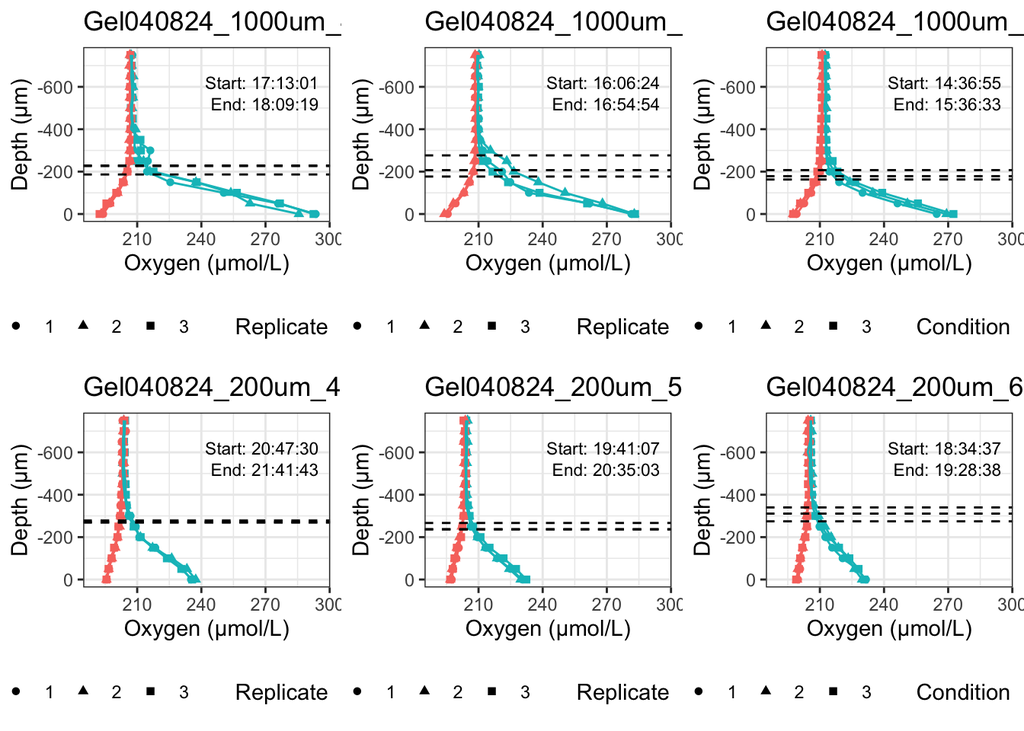

```r
arranged_plots <- arrangeGrob(grobs = plot_list, ncol = 3)
gridExtra::grid.arrange(arranged_plots)
```

```r
ggsave("Polymerized040824_Measured041024_plots_DBL.pdf", arranged_plots, width = 16, height = 9, units = "in", device = "pdf")
```

## Second Dataset, 4/12/24

Analyze dataset from 4/12/24, for the gels made on 4/10/24. There is an n = 3 for each thickness, with 3 gels of 200 um thickness (“thin”) and 3 gels of 1000 um thickness (“thick”). Three profiles were taken per gel, at a light intensity of PAR 90 umol/m^2/s and a flow rate of 0.5 cm/s. Three additional profiles were taken per gel in the dark after 20 minutes of dark adaptation. The profiles were taken in the middle of the hydrogel, in the same position for all 6 profiles per gel. For this dataset, I began taking profiles into the depth of the gel, which is shown in “positive” depths.

### Plotting profiles

```r
files <- list.files(path = "./Polymerized041024_Measured041224", pattern = "\\.csv$", full.names = TRUE)

plot_list <- list()

for (file in files) {
  file_name <- tools::file_path_sans_ext(basename(file))

  file_data <- read_csv(paste(file),show_col_types = FALSE) %>%
    mutate(Replicate = as.factor(Replicate)) %>%
    rename("Oxygen (µmol/L)" = `A FireSting Ch1 (µmol/L)`) %>% filter(Condition == "Light" | Condition == "Dark")

  plot <- ggplot(data = file_data, aes(y = `Oxygen (µmol/L)`, x = `Depth (µm)`,
                                       color = `Condition`, shape = `Replicate`)) +
      geom_point() + geom_line() +
      coord_flip() + scale_x_reverse() + xlim(1000, -1450) + ylim(140, 405) +
      geom_vline(xintercept = 0, linetype = 3) +
      theme_bw() + ggtitle(file_name) +
      annotate("text", x = -1400, y = 395, label = paste("Start:", file_data$Time[1]), vjust = 1, hjust = 1, size = 3) +
      annotate("text", x = -1300, y = 395, label = paste("End:", file_data$Time[nrow(file_data)]), vjust = 1, hjust = 1, size = 3) +
    theme(legend.position = "bottom")

  #print(plot)

  plot_list[[file_name]] <- plot
}
```

```
## the existing scale.
## the existing scale.
## the existing scale.
## the existing scale.
## the existing scale.
## the existing scale.
```

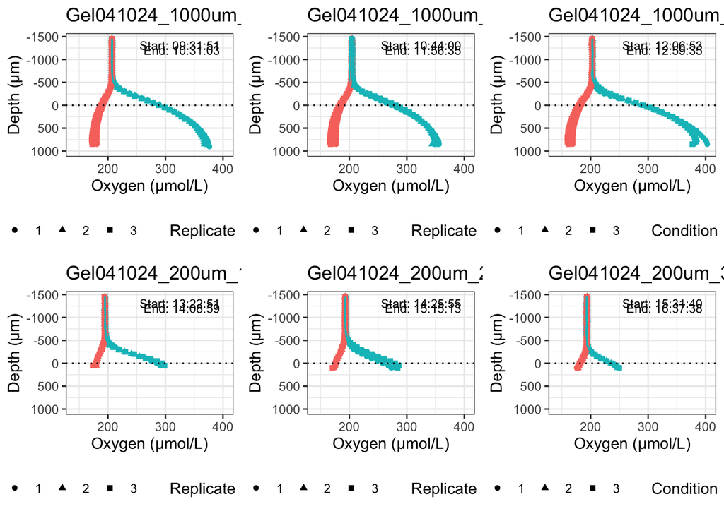

```r
arranged_plots <- arrangeGrob(grobs = plot_list, ncol = 3)
gridExtra::grid.arrange(arranged_plots)
```

```r
ggsave("Polymerized041024_Measured041224_plots.pdf", arranged_plots, width = 16, height = 9, units = "in", device = "pdf")
```

Extra profiles taken not plotted above:

```r
files <- c("./Polymerized041024_Measured041224/Gel041024_1000um_1.csv", "./Polymerized041024_Measured041224/Gel041024_200um_3.csv")

plot_list <- list()

for (file in files) {
  file_name <- tools::file_path_sans_ext(basename(file))

  file_data <- read_csv(paste(file),show_col_types = FALSE) %>%
    mutate(Replicate = as.factor(Replicate)) %>%
    rename("Oxygen (µmol/L)" = `A FireSting Ch1 (µmol/L)`) %>% filter(Condition != "Light" & Condition != "Dark")

 plot <- ggplot(data = file_data, aes(y = `Oxygen (µmol/L)`, x = `Depth (µm)`,
                                       color = `Condition`, shape = `Replicate`)) +
      geom_point() + geom_line() +
      coord_flip() + scale_x_reverse() + xlim(0, -1450) +
      geom_vline(xintercept = 0, linetype = 3) +
      theme_bw() + ggtitle(file_name) +
      annotate("text", x = -1400, y = 295, label = paste("Start:", file_data$Time[1]), vjust = 1, hjust = 1, size = 3) +
      annotate("text", x = -1300, y = 295, label = paste("End:", file_data$Time[nrow(file_data)]), vjust = 1, hjust = 1, size = 3) +
    theme(legend.position = "bottom")

  #print(plot)

  plot_list[[file_name]] <- plot
}
```

```
## the existing scale.
## the existing scale.
```

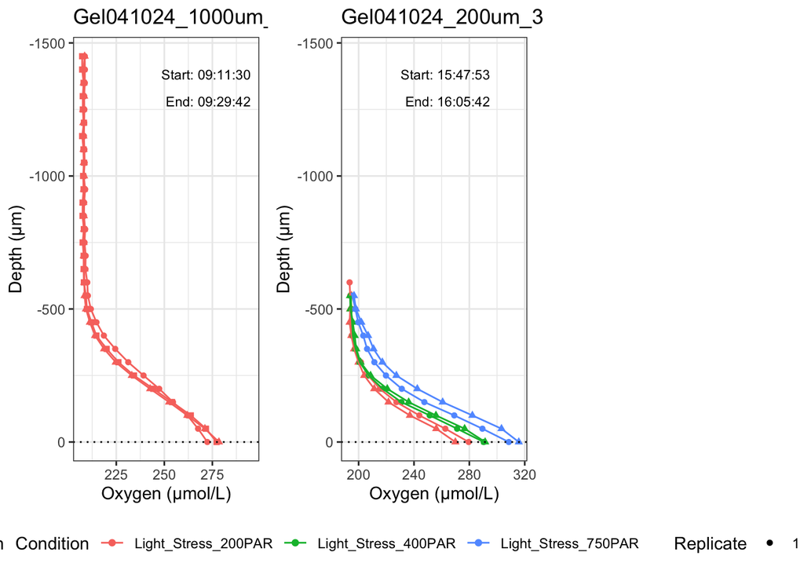

```r
arranged_plots <- arrangeGrob(grobs = plot_list, ncol = 3)
gridExtra::grid.arrange(arranged_plots)
```

```r
ggsave("Polymerized041024_Measured041224_plots_extra.pdf", arranged_plots, width = 16, height = 9, units = "in", device = "pdf")
```

### Using segmented linear regression, segmented R package

```r
library(segmented)

# Function to perform segmented regression and extract slope after breakpoint
perform_segmented_regression <- function(oxygen_concentration, depth) {
  # Fit segmented regression model
  fit <- segmented(lm(oxygen_concentration ~ depth), seg.Z = ~depth, psi = -500)

  # Extract the breakpoint(s)
  breakpoint <- fit$psi[, 2]

  # Find the index of the datapoint nearest to the breakpoint
  breakpoint_index <- which.min(abs(depth - breakpoint))

  # Extract the oxygen concentration at the breakpoint
  Oxygen_breakpoint <- oxygen_concentration[breakpoint_index]

  # Extract the oxygen concentration at depth = 0
  Oxygen_Surface <- oxygen_concentration[which(depth == 0)]

  # Extract the slope after the breakpoint for each segment
  lm_fit <- lm(oxygen_concentration ~ depth,
                 data = data.frame(depth = depth[breakpoint_index:length(depth)],
                                   oxygen_concentration = oxygen_concentration[breakpoint_index:length(oxygen_concentration)]))
  slope <- coef(lm_fit)["depth"]

  return(list(
    slope = slope,
    breakpoint = breakpoint,
    Oxygen_breakpoint = Oxygen_breakpoint,
    Oxygen_Surface = Oxygen_Surface
  ))
}

results_df_1000um_segmented <- data.frame(
  File = character(),
  Scaffold_Thickness = character(),
  Replicate = character(),
  slope = numeric(),
  Flux = numeric(),
  Breakpoint = numeric(),
  Oxygen_Surface = numeric(),
  Oxygen_breakpoint = numeric(),
  stringsAsFactors = FALSE
)

# Get list of CSV file names with "1000" in the title
file_list <- list.files(path = "./Polymerized041024_Measured041224", pattern = "1000.*\\.csv$", full.names = TRUE)

# Loop over files
for (file_path in file_list) {
  # Read data from file
  data <- read_csv(file_path, show_col_types = FALSE) %>%
    mutate(Replicate = as.factor(Replicate)) %>%
    rename("Oxygen (µmol/L)" = `A FireSting Ch1 (µmol/L)`) %>%
    arrange(`Depth (µm)`)

  # Loop over replicates
  for (replicate_id in unique(data$Replicate)) {
    # Subset data for the current replicate
    replicate_data <- data %>%
      filter(Replicate == replicate_id & Condition == "Light")

    # Extract oxygen concentration and depth
    oxygen_concentration <- replicate_data %>% pull(`Oxygen (µmol/L)`)
    depth <- replicate_data %>% pull(`Depth (µm)`)

    # Perform segmented regression
    regression_results <- perform_segmented_regression(oxygen_concentration, depth)

    # Calculate flux using Fick’s first law of diffusion
    DO2 <- 2.2417e-5  # Diffusion coefficient of oxygen
    flux <- -DO2 * regression_results$slope

    # Store results in dataframe
    results_df_1000um_segmented <- bind_rows(results_df_1000um_segmented, data.frame(
      File = basename(file_path),
      Scaffold_Thickness = "1000 um",
      Replicate = replicate_id,
      slope = regression_results$slope,
      Flux = flux,
      Breakpoint = regression_results$breakpoint,
      Oxygen_Surface = regression_results$Oxygen_Surface,
      Oxygen_breakpoint = regression_results$Oxygen_breakpoint,
      stringsAsFactors = FALSE
    ))
  }
}
# Print the results dataframe
print(results_df_1000um_segmented)
```

```
##                             File Scaffold_Thickness Replicate     slope
## depth...1 Gel041024_1000um_1.csv            1000 um         1 0.1335285
## depth...2 Gel041024_1000um_1.csv            1000 um         2 0.1331459
## depth...3 Gel041024_1000um_1.csv            1000 um         3 0.1352823
## depth...4 Gel041024_1000um_2.csv            1000 um         1 0.1264087
## depth...5 Gel041024_1000um_2.csv            1000 um         2 0.1200973
## depth...6 Gel041024_1000um_2.csv            1000 um         3 0.1205591
## depth...7 Gel041024_1000um_3.csv            1000 um         1 0.1724841
## depth...8 Gel041024_1000um_3.csv            1000 um         2 0.1530247
## depth...9 Gel041024_1000um_3.csv            1000 um         3 0.1507974
##                    Flux Breakpoint Oxygen_Surface Oxygen_breakpoint
## depth...1 -2.993308e-06  -556.7118        288.860           208.705
## depth...2 -2.984731e-06  -553.1858        289.131           208.382
## depth...3 -3.032624e-06  -539.6768        288.271           208.501
## depth...4 -2.833704e-06  -494.3934        273.166           208.080
## depth...5 -2.692220e-06  -535.8614        275.934           206.864
## depth...6 -2.702574e-06  -561.2045        280.751           205.643
## depth...7 -3.866576e-06  -455.3708        288.669           207.097
## depth...8 -3.430354e-06  -521.2498        287.524           206.080
## depth...9 -3.380425e-06  -534.2563        291.139           205.244
```

```r
results_df_200um_segmented <- data.frame(
  File = character(),
  Scaffold_Thickness = character(),
  Replicate = character(),
  slope = numeric(),
  Flux = numeric(),
  Breakpoint = numeric(),
  Oxygen_Surface = numeric(),
  Oxygen_breakpoint = numeric(),
  stringsAsFactors = FALSE
)

# Get list of CSV file names with "200" in the title
file_list <- list.files(path = "./Polymerized041024_Measured041224", pattern = "200.*\\.csv$", full.names = TRUE)

# Loop over files
for (file_path in file_list) {
  # Read data from file
  data <- read_csv(file_path, show_col_types = FALSE) %>%
    mutate(Replicate = as.factor(Replicate)) %>%
    rename("Oxygen (µmol/L)" = `A FireSting Ch1 (µmol/L)`) %>%
    arrange(`Depth (µm)`)

  # Loop over replicates
  for (replicate_id in unique(data$Replicate)) {
    # Subset data for the current replicate
    replicate_data <- data %>%
      filter(Replicate == replicate_id & Condition == "Light")

    # Extract oxygen concentration and depth
    oxygen_concentration <- replicate_data %>% pull(`Oxygen (µmol/L)`)
    depth <- replicate_data %>% pull(`Depth (µm)`)

    # Perform segmented regression
    regression_results <- perform_segmented_regression(oxygen_concentration, depth)

    # Calculate flux using Fick’s first law of diffusion
    DO2 <- 2.2417e-5  # Diffusion coefficient of oxygen
    flux <- -DO2 * regression_results$slope

    # Store results in dataframe
    results_df_200um_segmented <- bind_rows(results_df_200um_segmented, data.frame(
      File = basename(file_path),
      Scaffold_Thickness = "200 um",
      Replicate = replicate_id,
      slope = regression_results$slope,
      Flux = flux,
      Breakpoint = regression_results$breakpoint,
      Oxygen_Surface = regression_results$Oxygen_Surface,
      Oxygen_breakpoint = regression_results$Oxygen_breakpoint,
      stringsAsFactors = FALSE
    ))
  }
}
# Print the results dataframe
print(results_df_200um_segmented)
```

```
##                            File Scaffold_Thickness Replicate     slope
## depth...1 Gel041024_200um_1.csv             200 um         1 0.1901625
## depth...2 Gel041024_200um_1.csv             200 um         2 0.2150055
## depth...3 Gel041024_200um_1.csv             200 um         3 0.2360395
## depth...4 Gel041024_200um_2.csv             200 um         1 0.1630044
## depth...5 Gel041024_200um_2.csv             200 um         2 0.1640239
## depth...6 Gel041024_200um_2.csv             200 um         3 0.1711059
## depth...7 Gel041024_200um_3.csv             200 um         1 0.1479652
## depth...8 Gel041024_200um_3.csv             200 um         2 0.1335513
## depth...9 Gel041024_200um_3.csv             200 um         3 0.1404880
##                    Flux Breakpoint Oxygen_Surface Oxygen_breakpoint
## depth...1 -4.262874e-06  -425.9751        284.485           202.745
## depth...2 -4.819777e-06  -410.2388        289.267           205.874
## depth...3 -5.291298e-06  -407.2493        294.029           202.154
## depth...4 -3.654069e-06  -369.7021        258.055           204.006
## depth...5 -3.676924e-06  -429.2566        272.079           200.391
## depth...6 -3.835680e-06  -469.2151        279.738           201.503
## depth...7 -3.316937e-06  -270.8908        234.767           199.971
## depth...8 -2.993820e-06  -279.3552        235.705           198.117
## depth...9 -3.149319e-06  -278.0516        236.974           197.286
```

```r
Full_results_segmented <- rbind(results_df_1000um_segmented, results_df_200um_segmented)

Full_results_segmented
```

```
##                              File Scaffold_Thickness Replicate     slope
## depth...1  Gel041024_1000um_1.csv            1000 um         1 0.1335285
## depth...2  Gel041024_1000um_1.csv            1000 um         2 0.1331459
## depth...3  Gel041024_1000um_1.csv            1000 um         3 0.1352823
## depth...4  Gel041024_1000um_2.csv            1000 um         1 0.1264087
## depth...5  Gel041024_1000um_2.csv            1000 um         2 0.1200973
## depth...6  Gel041024_1000um_2.csv            1000 um         3 0.1205591
## depth...7  Gel041024_1000um_3.csv            1000 um         1 0.1724841
## depth...8  Gel041024_1000um_3.csv            1000 um         2 0.1530247
## depth...9  Gel041024_1000um_3.csv            1000 um         3 0.1507974
## depth...11  Gel041024_200um_1.csv             200 um         1 0.1901625
## depth...21  Gel041024_200um_1.csv             200 um         2 0.2150055
## depth...31  Gel041024_200um_1.csv             200 um         3 0.2360395
## depth...41  Gel041024_200um_2.csv             200 um         1 0.1630044
## depth...51  Gel041024_200um_2.csv             200 um         2 0.1640239
## depth...61  Gel041024_200um_2.csv             200 um         3 0.1711059
## depth...71  Gel041024_200um_3.csv             200 um         1 0.1479652
## depth...81  Gel041024_200um_3.csv             200 um         2 0.1335513
## depth...91  Gel041024_200um_3.csv             200 um         3 0.1404880
##                     Flux Breakpoint Oxygen_Surface Oxygen_breakpoint
## depth...1  -2.993308e-06  -556.7118        288.860           208.705
## depth...2  -2.984731e-06  -553.1858        289.131           208.382
## depth...3  -3.032624e-06  -539.6768        288.271           208.501
## depth...4  -2.833704e-06  -494.3934        273.166           208.080
## depth...5  -2.692220e-06  -535.8614        275.934           206.864
## depth...6  -2.702574e-06  -561.2045        280.751           205.643
## depth...7  -3.866576e-06  -455.3708        288.669           207.097
## depth...8  -3.430354e-06  -521.2498        287.524           206.080
## depth...9  -3.380425e-06  -534.2563        291.139           205.244
## depth...11 -4.262874e-06  -425.9751        284.485           202.745
## depth...21 -4.819777e-06  -410.2388        289.267           205.874
## depth...31 -5.291298e-06  -407.2493        294.029           202.154
## depth...41 -3.654069e-06  -369.7021        258.055           204.006
## depth...51 -3.676924e-06  -429.2566        272.079           200.391
## depth...61 -3.835680e-06  -469.2151        279.738           201.503
## depth...71 -3.316937e-06  -270.8908        234.767           199.971
## depth...81 -2.993820e-06  -279.3552        235.705           198.117
## depth...91 -3.149319e-06  -278.0516        236.974           197.286
```

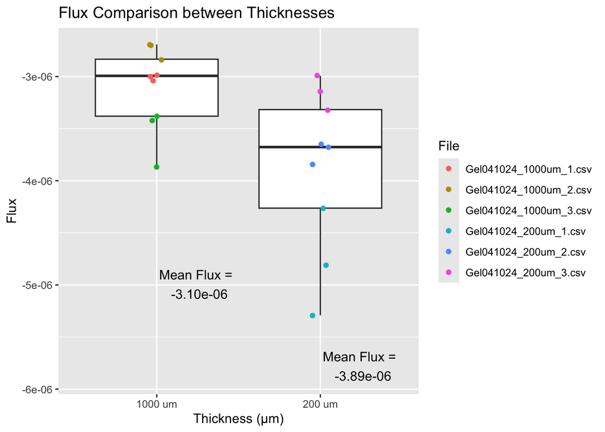

```r
mean_flux <- Full_results_segmented %>%
  group_by(Scaffold_Thickness) %>%
  summarize(mean_flux = mean(Flux))

# Plotting the flux values for each thickness
ggplot(Full_results_segmented, aes(x = Scaffold_Thickness, y = Flux)) +
  geom_boxplot() + geom_point(aes(color = File), position = position_jitter(width = 0.05)) +
  geom_text(data = mean_flux, aes(label = paste("Mean Flux = \n", sprintf("%.2e", mean_flux)), y = mean_flux-.000002), vjust = 0.1, position = position_nudge(x = 0.25)) +
  labs(x = "Thickness (µm)", y = "Flux") +
  ggtitle("Flux Comparison between Thicknesses")
```

```r
# Running ANOVA
anova_result <- aov(Flux ~ Scaffold_Thickness, data = Full_results_segmented)
summary(anova_result)
```

```
##                    Df    Sum Sq   Mean Sq F value Pr(>F)
## Scaffold_Thickness  1 2.788e-12 2.788e-12   7.496 0.0146 *
## Residuals          16 5.951e-12 3.719e-13
## ---
## Signif. codes:  0 '***' 0.001 '**' 0.01 '*' 0.05 '.' 0.1 ' ' 1
```

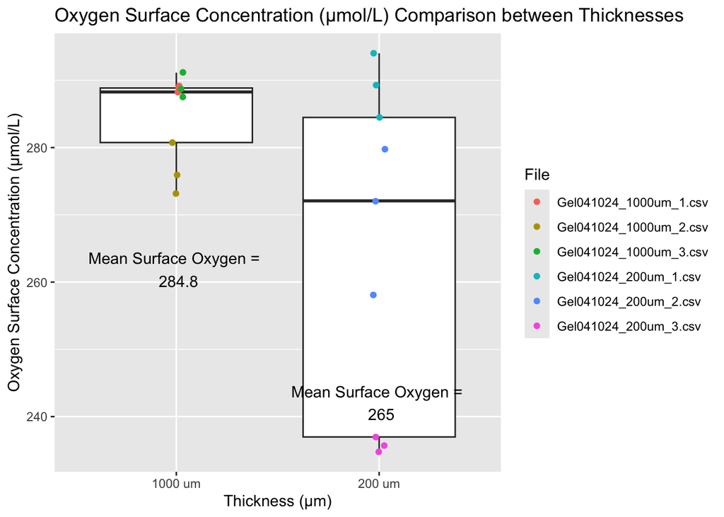

```r
# What about for oxygen surface concentration?

mean_Oxygen_Surface <- Full_results_segmented %>%
  group_by(Scaffold_Thickness) %>%
  summarize(mean_Oxygen_Surface = mean(Oxygen_Surface))

# Plotting the surface O2 values for each thickness
ggplot(Full_results_segmented, aes(x = Scaffold_Thickness, y = Oxygen_Surface)) +
  geom_boxplot() + geom_point(aes(color = File), position = position_jitter(width = 0.05)) +
  geom_text(data = mean_Oxygen_Surface, aes(label = paste("Mean Surface Oxygen = \n", round(mean_Oxygen_Surface, 1)), y = mean_Oxygen_Surface-25), vjust = 0.1, position = position_nudge(x = 0.0)) +
  labs(x = "Thickness (µm)", y = "Oxygen Surface Concentration (µmol/L)") +
  ggtitle("Oxygen Surface Concentration (µmol/L) Comparison between Thicknesses")
```

```r
# Running ANOVA
anova_result <- aov(Oxygen_Surface ~ Scaffold_Thickness, data = Full_results_segmented)
summary(anova_result)
```

```
##                    Df Sum Sq Mean Sq F value Pr(>F)
## Scaffold_Thickness  1   1767    1767   5.627 0.0306 *
## Residuals          16   5025     314
## ---
## Signif. codes:  0 '***' 0.001 '**' 0.01 '*' 0.05 '.' 0.1 ' ' 1
```

### Plotting profiles with DBL

```r
files <- list.files(path = "./Polymerized041024_Measured041224", pattern = "\\.csv$", full.names = TRUE)

plot_list <- list()

for (file in files) {
  file_name <- tools::file_path_sans_ext(basename(file))

  file_data <- read_csv(paste(file),show_col_types = FALSE) %>%
    mutate(Replicate = as.factor(Replicate)) %>%
    rename("Oxygen (µmol/L)" = `A FireSting Ch1 (µmol/L)`) %>% filter(Condition == "Light" | Condition == "Dark")

  # Extract the DBL depth for the current file
  dbl_depth <- Full_results_segmented$Breakpoint[gsub("\\.csv$", "", Full_results_segmented$File) == file_name]

  plot <- ggplot(data = file_data, aes(y = `Oxygen (µmol/L)`, x = `Depth (µm)`,
                                       color = `Condition`, shape = `Replicate`)) +
      geom_point() + geom_line() +
      coord_flip() + scale_x_reverse() + xlim(0, -1000) + ylim(140, 405) +
      theme_bw() + ggtitle(file_name) +
      annotate("text", x = -900, y = 395, label = paste("Start:", file_data$Time[1]), vjust = 1, hjust = 1, size = 3) +
      annotate("text", x = -850, y = 395, label = paste("End:", file_data$Time[nrow(file_data)]), vjust = 1, hjust = 1, size = 3) +
      geom_vline(xintercept = dbl_depth, linetype = "dashed") +  # Add DBL depth line
      theme(legend.position = "bottom")

  #print(plot)

  plot_list[[file_name]] <- plot
}
```

```
## the existing scale.
## the existing scale.
## the existing scale.
## the existing scale.
## the existing scale.
## the existing scale.
```

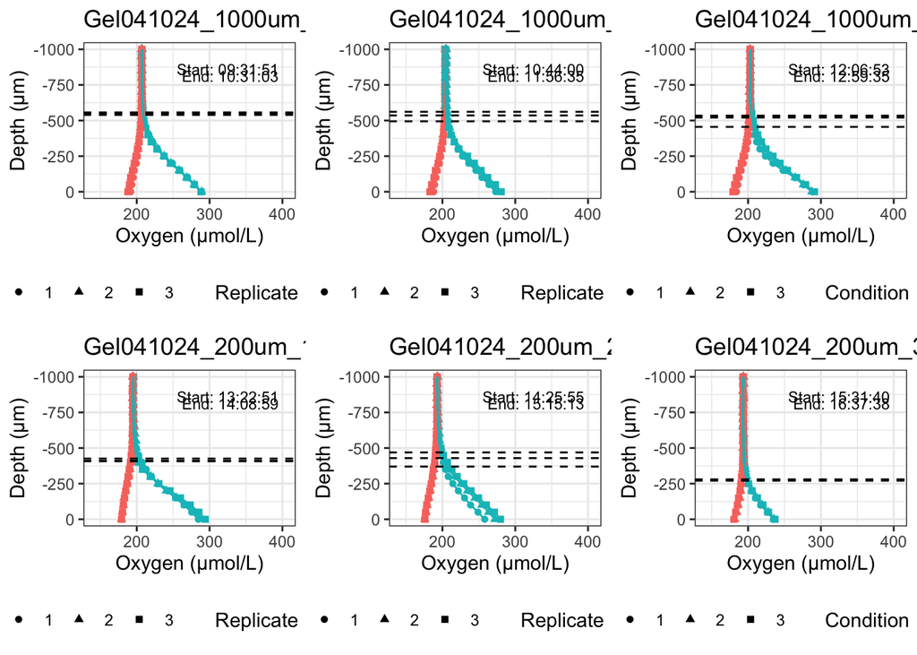

```r
arranged_plots <- arrangeGrob(grobs = plot_list, ncol = 3)
gridExtra::grid.arrange(arranged_plots)
```

```r
ggsave("Polymerized041024_Measured041224_plots_DBL.pdf", arranged_plots, width = 16, height = 9, units = "in", device = "pdf")
```

## Third Dataset, 4/13/24

Analyze dataset from 4/13/24, for the gels (numbered 1-3) made on 4/08/24. These gels were stressed out using high light (PAR 630 umol/m^2/s) for two hours from 9AM-11AM in the morning in the incubator they were kept in and then held at ambient light (PAR = 90) until profiles were taken. There is an n = 3 for each thickness, with 3 gels of 200 um thickness (“thin”) and 3 gels of 1000 um thickness (“thick”). Three profiles were taken per gel, at a light intensity of PAR 90 umol/m^2/s and a flow rate of 0.5 cm/s. Three additional profiles were taken per gel in high light (PAR 630 umol/m^2/s) after 5-10 minutes of adaptation to equilibrium based on the oxygen surface concentration no longer increasing and reaching steady state. The profiles were taken in the middle of the hydrogel, in the same position for all 6 profiles per gel. Profiles were taken partially into the depth of the gel, which is shown in “positive” depths.

### Plotting profiles

```r
files <- list.files(path = "./Polymerized040824_Measured041324", pattern = "\\.csv$", full.names = TRUE)

plot_list <- list()

for (file in files) {
  file_name <- tools::file_path_sans_ext(basename(file))

  file_data <- read_csv(paste(file),show_col_types = FALSE) %>%
    mutate(Replicate = as.factor(Replicate)) %>%
    rename("Oxygen (µmol/L)" = `A FireSting Ch1 (µmol/L)`) #%>% filter(Condition == "Light" | Condition == "Dark")

  plot <- ggplot(data = file_data, aes(y = `Oxygen (µmol/L)`, x = `Depth (µm)`,
                                       color = `Condition`, shape = `Replicate`)) +
      geom_point() + geom_line() +
      coord_flip() + scale_x_reverse() + xlim(1000, -1450) + ylim(200, 900) +
      geom_vline(xintercept = 0, linetype = 3) +
      theme_bw() + ggtitle(file_name) +
      annotate("text", x = -1400, y = 395, label = paste("Start:", file_data$Time[1]), vjust = 1, hjust = 1, size = 3) +
      annotate("text", x = -1300, y = 395, label = paste("End:", file_data$Time[nrow(file_data)]), vjust = 1, hjust = 1, size = 3) +
    theme(legend.position = "bottom")

  #print(plot)

  plot_list[[file_name]] <- plot
}
```

```
## the existing scale.
## the existing scale.
## the existing scale.
## the existing scale.
## the existing scale.
## the existing scale.
```

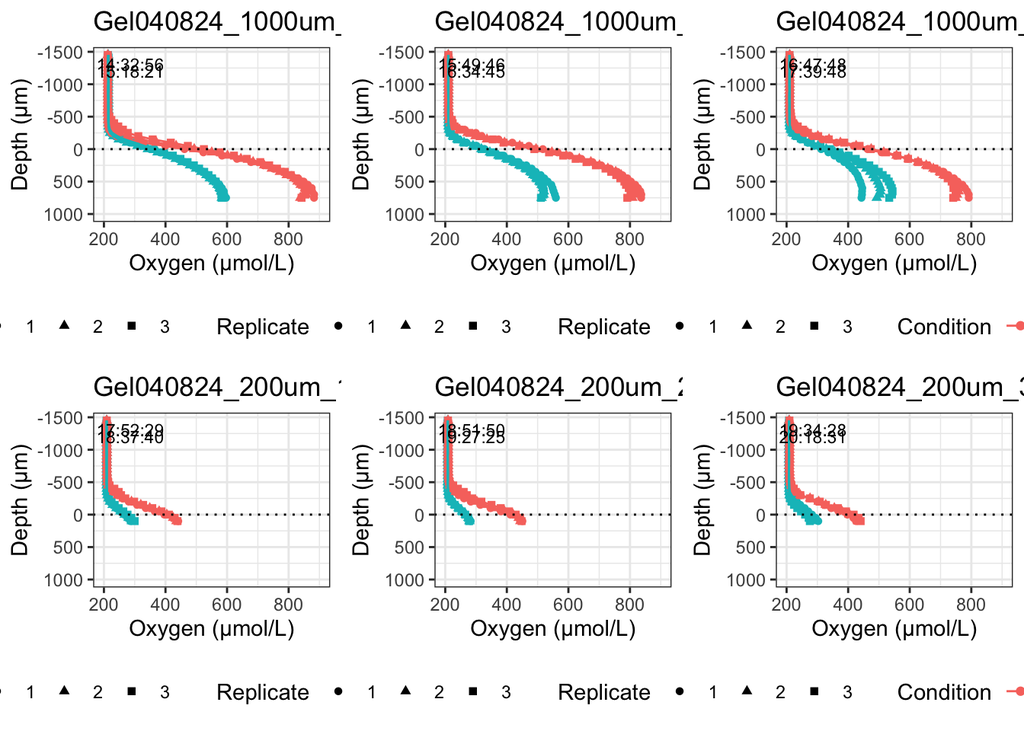

```r
arranged_plots <- arrangeGrob(grobs = plot_list, ncol = 3)

gridExtra::grid.arrange(arranged_plots)
```

```r
ggsave("Polymerized040824_Measured041324_plots.pdf", arranged_plots, width = 16, height = 9, units = "in", device = "pdf")
```